# Math 120 Week 8

Ali Miller

12 October, 2020

# Monday Oct 5

## Probability Trees

Probability trees provide a handy visual aid for organizing all of the various probabilities we care about.

*Ex* Suppose a test for a disease advertises itself as “95% accurrate. This means: if the test is administered to someone who *has* the disease, the test will show”+" 95% of the time.

Suppose that if a person doesn’t have the disease, then they’ll test “-” about 85%.

Suppose that 3% of the population has the disease.

Let’s draw a probability tree to summarize the probabilities.

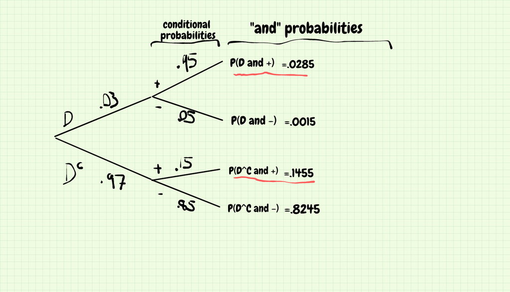

List of Probabilities:

P(+|D) = .95 P(-|D) = .05 P(+|D^C) = .15 P(-|D^C) = .85

P(+ and D) = .03*.95

```r
.03*.95
```

```
## [1] 0.0285
```

P(D and -) = .03*.05

```r
.03*.05
```

```
## [1] 0.0015
```

```r
.97*.15
```

```
## [1] 0.1455
```

```r
.97*.85
```

```
## [1] 0.8245
```

In summary, the tree gives and intuitive layout for all conditional probabilities and “and” probabilites.

Two important uses:

1. Q: what percent of people test positive? Can easily figure it out from the tree. There’s only four possibilities!

Want to find: P(+)? There are only two options for this scenario: D and + or D^D and +. So, add up the probabilities!

P(+) = .0285 + .1455

```r
.0285+.1455
```

```
## [1] 0.174
```

About 17.4% of all people in the population will test positive.

2. What’s the probability that, if you test +, you actually have the disease?? Observations:
- this is what YOU care about if you’re taking the test!
- “backwards” from what we have right now! RIght now, we know P(+|D). We want the other way: P( D | +)?

From the tree, we know everyting. Use the conditional probability formula:

```
P(D|+) =  P(D and +)/P(+) = .0285/.174
```

```r
.0285/.174
```

```
## [1] 0.1637931
```

If you test positive, there’s only about 16.4% chance that you really do have the disease! Woah!

Notes:

- 1 above is the “law of total probability”. To find P(+), we added all the possible probabilities:

  P(+) = P(D and +) + P(D^C and +)
- 2 above is Bayes Rule! Bayes rule is a formula/law for “reversing” conditional probabilities. Here: we started with P(+|D). But actually, we’re interested in the probability P(D|+).

Recall, the test advertises itself as “95% accurate”. BUT, if you get a + result on the test, there’s only a 16.4% chance that you really have the disease!!

Think of Bayes this way: it reverses conditional probability using info from the tree and the definition of conditional probability.

**Example: Bayes** Suppose:

- 0.1% of the American population currently has lung cancer (event “L”)
- 90% of all lung cancer cases are smokers (event “S”)
- 21% of those without lung cancer also smoke.

(These values are fairly close to the values given on the American Lung Association web site

Construct a probability tree to find the following probabilities:

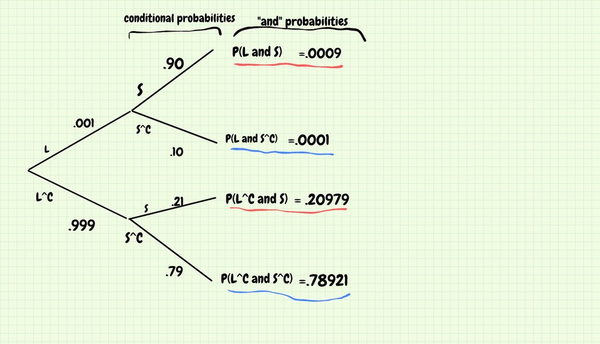

- P(S^C|L) = .1
- P(S and L^C) = .20979
- P(S) = .0009 + .20979 = 0.21069

```r
.0009 + .20979
```

```
## [1] 0.21069
```

- P(L|S) = P(L and S)/P(S) = .0009/.21069

```r
.0009/.21069
```

```
## [1] 0.004271679
```

- P(L|S^C) = P(L and S<sup>C)/P(S</sup>C) = .0001/(.0001+.78921)

```r
.0001/(.0001+.78921)
```

```
## [1] 0.0001266929
```

Q: how much more likely is it for a smoker to have lung cancer than a non-smoker?

Divide: smoking lung rate/non smoking rate:

```r
0.004271679/0.0001266929
```

```
## [1] 33.7168
```

Smokers are nearly 34 times more likely to have lung cancer!

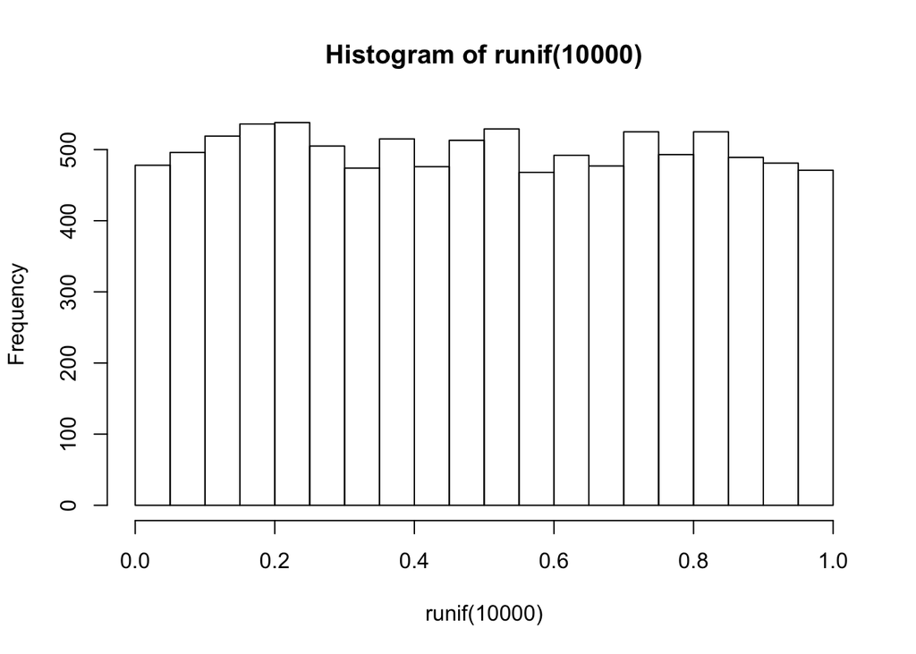

```r
hist(runif(10000))
```

# Friday 10-9

## Continuous Distributions - Normal Dist

Context: let’s get to know the most famous probability distribution: normal dist, ie, the bell curve.

Interesting fact: the normal dist arises naturally in many real life/data applications.

Cool fact: the normal dist is seen whenever we examine sums or **means** of random numbers.

```r
runif(1)
```

```
## [1] 0.9888744
```

Random real number between 0 and 1.

```r
runif(10)
```

```
##  [1] 0.09326363 0.33961417 0.53182268 0.33479325 0.68255577 0.01995429
##  [7] 0.26821884 0.73545766 0.25394996 0.88486811
```

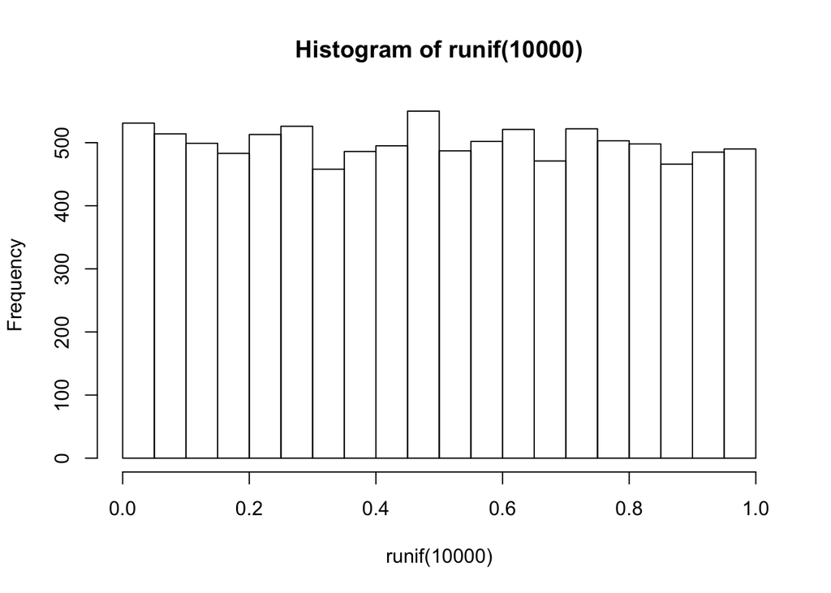

```r
hist(runif(10000))
```

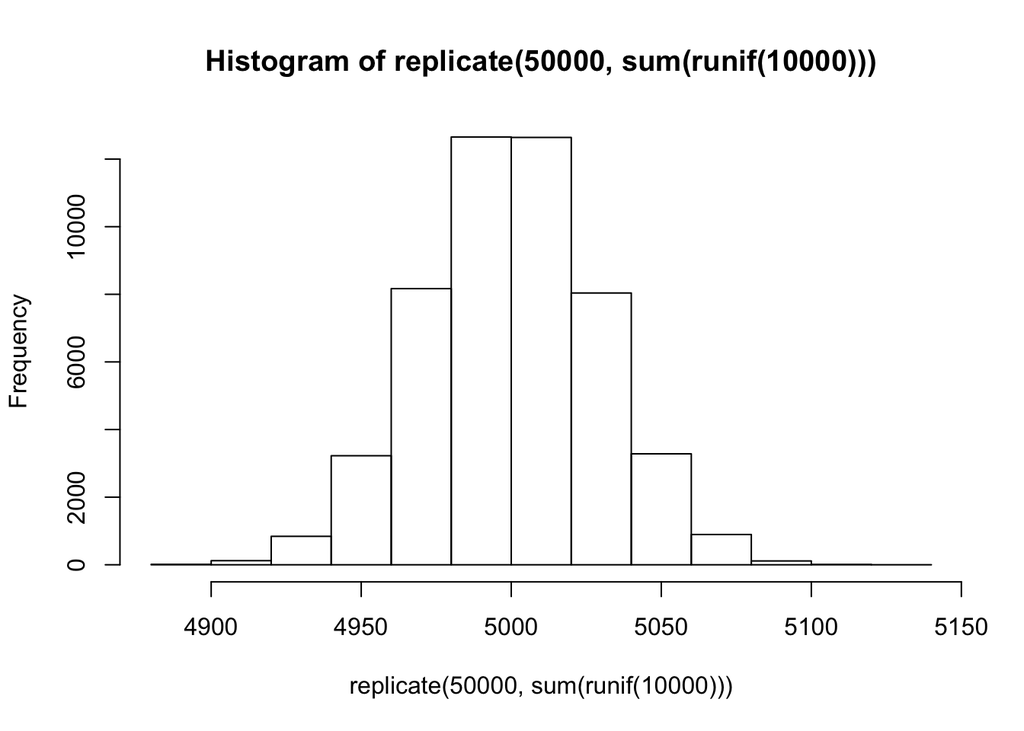

```r
hist(replicate(50000, sum(runif(10000))))
```

Moral of the story: any time we study averages of randomly selected number (each one from the same population), the means (or sums) will follow a normal dist.

Intuition: most values are in the middle. Very large (or very small) results are increasingly unlikely.

The normal dist also arises frequently in biological variables: ex human height is normally distributed.

Weird thing about the normal dist: it’s a “continuous” distribution. In other words, we can’t list out all the possible options for X.

Ex: Human height. Not possible to make list of all possible human heights. Infinitely many!

Because of this, we can’t make a distribution table!

Instead: use a density curve. To find probability for a normal dist, we need to find area under the density curve.

Ex: Height for adult men in the US follows a normal dist, with mean 69" and std 2.7".

What’s the probability that a randomly selected man is less than 70" tall?

What’s the probability that a randomly selecte man is between 67 and 68" tall?

**Problem** It’s easy to draw the picture, it’s hard to find the area! No simple geometric formula!

If you’ve taken calculus: this is an unsolvable integral! No closed-form solution!

So, we NEED computational assistance.

1. Refer to a table
2. Use software (including Google Sheets)

**One more problem** There are MANY normal distributions (depending on center and spread).

Answer: use the Standard Normal Dist, ie the normal distribution with center = 0 and spread (std dev) = 1.

To perform any of these computations, we’ll need to convert our data to a standard normal. (More on this later).

Let’s do some example computations.

NOTE: The standard normal distribution is ALWAYS denoted by “Z”.

*EX* Suppose Z has a standard normal dist. Compute the following:

1. P(Z<1.28) = .8997
2. P(Z>1.28) = 1 - P(Z<1.28) [complement rule]

```r
1-.8997
```

```
## [1] 0.1003
```

3. P( -0.82 < Z < 2.51 ) = P(Z<2.51) - P(Z< -0.82) = .9940 - .2061

```r
.9940 - .2061
```

```
## [1] 0.7879
```

Problem: if we look up z=2.51 in the table, we’ll get ALL the area below that cutoff. But that’s too much! So, let’s subtract off the area below -.82: